# Exploratory Data Analysis and Modeling - Assignment1

Li Xin

June 11, 2016

## Instructions

The goal of this project is just to display that you’ve gotten used to working with the data and that you are on track to create your prediction algorithm. Please submit a report on R Pubs (http://rpubs.com/) that explains your exploratory analysis and your goals for the eventual app and algorithm. This document should be concise and explain only the major features of the data you have identified and briefly summarize your plans for creating the prediction algorithm and Shiny app in a way that would be understandable to a non-data scientist manager. You should make use of tables and plots to illustrate important summaries of the data set. The motivation for this project is to: 1. Demonstrate that you’ve downloaded the data and have successfully loaded it in.2. Create a basic report of summary statistics about the data sets.3. Report any interesting findings that you amassed so far.4. Get feedback on your plans for creating a prediction algorithm and Shiny app.

## Data Processing

Load and scan the 3 files and count total lines of each file separately.

```r
#Count lines - Blogs

blog<-"./final/en_US/en_US.blogs.txt"
blog.text<-scan(blog,what="char",sep="\n")
blog.len<-length(blog.text)
blog.len
```

```
## [1] 899288
```

There are **899288** rows in blog file in total.

```r
#Count lines - Twitters

twitter<-"./final/en_US/en_US.twitter.txt"
twitter.text<-scan(twitter,what="char",sep="\n")
twitter.len<-length(twitter.text)
twitter.len
```

```
## [1] 2360148
```

There are **2360148** rows in twitter file in total.

```r
#Count lines - News

news<-"./final/en_US/en_US.news.txt"
news.text<-scan(news,what="char",sep="\n")
news.len<-length(news.text)
news.len
```

```
## [1] 77259
```

There are **77259** rows in news file in total.

## Get sample of Data

```r
# data.blog<-sample(blog,blog.len*0.01,replace=FALSE)
# data.twitter<-sample(twitter,twitter.len*0.01,replace=FALSE)
# data.news<-sample(news,news.len*0.01,replace=FALSE)

data.blog<-readLines(blog,blog.len/1000,encoding="latin1")
data.twitter<-readLines(twitter,twitter.len/1000,encoding="latin1")
data.news<-readLines(news,news.len/1000,encoding="latin1")

# closeAllConnections()

data.blog<-unlist(data.blog)
data.twitter<-unlist(data.twitter)
data.news<-unlist(data.news)


all<-paste(data.blog,data.twitter,data.news)
# all<-sent_detect(all,language="en",model=NULL)
```

## Transformation & Data Structure

```r
all.corpus<-VCorpus(VectorSource(all))
all.corpus<-tm_map(all.corpus,PlainTextDocument)
all.corpus<-tm_map(all.corpus,stripWhitespace)
all.corpus<-tm_map(all.corpus,removeNumbers)

# all.corpus<-tm_map(all.corpus,content_transformer(stringi::stri_trans_tolower(all.corpus)))
all.corpus<-tm_map(all.corpus,tolower)



# all.corpus<-tolower(all.corpus)
# all.corpus<-tm_map(all.corpus,removeWords,stopwords("english"))

#remove some common connected words.
# mystopwords <- c("and", "for", "in", "is", "it", "not", "the", "to")
# all.corpus<-tm_map(all.corpus,removeWords,mystopwords)

#remove stemming of words.
all.corpus<-tm_map(all.corpus,stemDocument)
# all.corpus<-gsub("^[:alnum:]","",all.corpus)

#removing symbols
# all.corpus<-gsub("[:punct:]","",all.corpus)
# # all.corpus<-gsub("[:punct:]","",all.corpus)
# all.corpus<-gsub("\\","",all.corpus,fixed=TRUE)
all.corpus<-tm_map(all.corpus,removePunctuation)
```

Tokenlize and create 1-gram, 2-gram, 3-gram algorithms for analysis.

```r
# cleantext<-data.frame(text=unlist(sapply(all.corpus, `[`, "content")), stringsAsFactors=F)
# head(cleantext, n=6)

one.Gram<-NGramTokenizer(all.corpus,Weka_control(min=1,max=1))
two.Gram<-NGramTokenizer(all.corpus,Weka_control(min=2,max=2))
thr.Gram<-NGramTokenizer(all.corpus,Weka_control(min=3,max=3))
fou.Gram<-NGramTokenizer(all.corpus,Weka_control(min=4,max=4))

# inspect(two.Gram.text)
# fou.Gram.text<-NGramTokenizer(all.corpus,Weka_control(min=3,max=3,delimiters="\\r\\n\\t.,;:\"()?!"))

# one.Gram.Tab<-as.table(one.Gram)
one.Gram.fra<-data.frame(table(one.Gram))
one.Gram.Sort<-one.Gram.fra[order(one.Gram.fra$Freq,decreasing = TRUE),]
one.Gram.Top20<-one.Gram.Sort[1:20,]
colnames(one.Gram.Top20) <- c("Word","Frequency")
one.Gram.Top20$Word<-factor(one.Gram.Top20$Word,levels=one.Gram.Top20$Word[order(one.Gram.Top20$Frequency,decreasing = TRUE)])

two.Gram.fra<-data.frame(table(two.Gram))
two.Gram.Sort<-two.Gram.fra[order(two.Gram.fra$Freq,decreasing = TRUE),]
two.Gram.Top20<-two.Gram.Sort[1:20,]
colnames(two.Gram.Top20) <- c("Word","Frequency")
two.Gram.Top20$Word<-factor(two.Gram.Top20$Word,levels=two.Gram.Top20$Word[order(two.Gram.Top20$Frequency,decreasing = TRUE)])

thr.Gram.fra<-data.frame(table(thr.Gram))
thr.Gram.Sort<-thr.Gram.fra[order(thr.Gram.fra$Freq,decreasing = TRUE),]
thr.Gram.Top20<-thr.Gram.Sort[1:20,]
colnames(thr.Gram.Top20) <- c("Word","Frequency")
thr.Gram.Top20$Word<-factor(thr.Gram.Top20$Word,levels=thr.Gram.Top20$Word[order(thr.Gram.Top20$Frequency,decreasing = TRUE)])

fou.Gram.fra<-data.frame(table(fou.Gram))
fou.Gram.Sort<-fou.Gram.fra[order(fou.Gram.fra$Freq,decreasing = TRUE),]
fou.Gram.Top20<-fou.Gram.Sort[1:20,]
colnames(fou.Gram.Top20) <- c("Word","Frequency")
fou.Gram.Top20$Word<-factor(fou.Gram.Top20$Word,levels=fou.Gram.Top20$Word[order(fou.Gram.Top20$Frequency,decreasing = TRUE)])
```

## Plot

Using ggplot to display top 20 frequency words with 1,2,3-gram analysis.

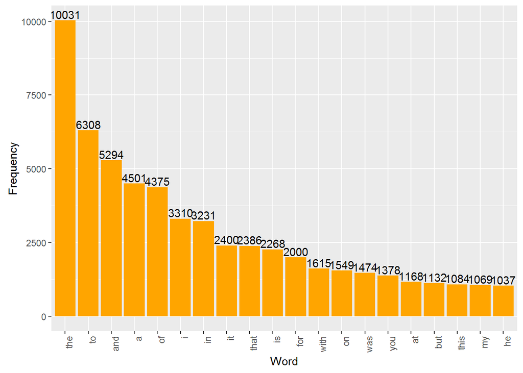

```r
#rank of top 20 1-gram words
ggplot(one.Gram.Top20,aes(x=Word,y=Frequency))+geom_bar(stat="Identity",fill="orange")+geom_text(aes(label=Frequency),vjust=-0.2)+theme(axis.text.x = element_text(angle = 90, hjust = 1))
```

```r
##table of top 20 1-gram words
head(one.Gram.Top20,20)
```

```
##       Word Frequency
## 10281  the     10031
## 10444   to      6308
## 523    and      5294
## 1        a      4501
## 7138    of      4375
## 5057     i      3310
## 5175    in      3231
## 5436    it      2400
## 10269 that      2386
## 5413    is      2268
## 4046   for      2000
## 11344 with      1615
## 7190    on      1549
## 11118  was      1474
## 11554  you      1378
## 777     at      1168
## 1545   but      1132
## 10344 this      1084
## 6803    my      1069
## 4724    he      1037
```

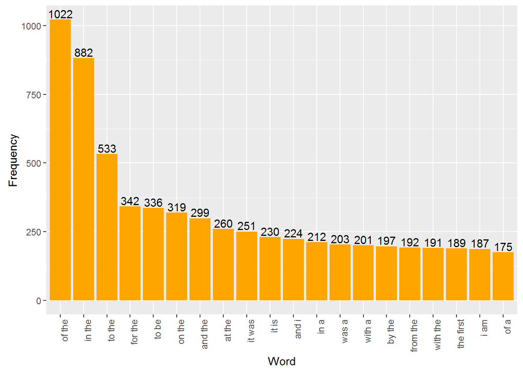

```r
#rank of top 20 2-gram words
ggplot(two.Gram.Top20,aes(x=Word,y=Frequency))+geom_bar(stat="Identity",fill="orange")+geom_text(aes(label=Frequency),vjust=-0.2)+theme(axis.text.x = element_text(angle = 90, hjust = 1))
```

```r
##table of top 20 1-gram words
head(two.Gram.Top20,20)
```

```
##            Word Frequency
## 30280    of the      1022
## 21418    in the       882
## 45186    to the       533
## 15764   for the       342
## 44565     to be       336
## 30833    on the       319
## 3635    and the       299
## 4957     at the       260
## 22698    it was       251
## 22556     it is       230
## 3230      and i       224
## 21076      in a       212
## 47667     was a       203
## 49582    with a       201
## 8107     by the       197
## 16304  from the       192
## 49795  with the       191
## 41787 the first       189
## 20232      i am       187
## 29775      of a       175
```

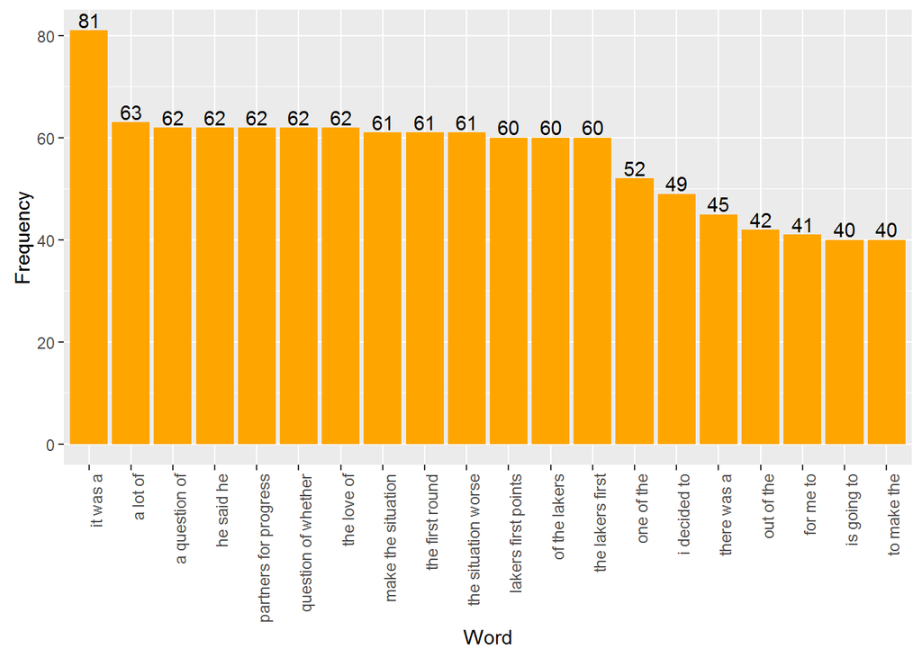

```r
#rank of top 20 3-gram words
ggplot(thr.Gram.Top20,aes(x=Word,y=Frequency))+geom_bar(stat="Identity",fill="orange")+geom_text(aes(label=Frequency),vjust=-0.2)+theme(axis.text.x = element_text(angle = 90, hjust = 1))
```

```r
##table of top 20 1-gram words
head(thr.Gram.Top20,20)
```

```
##                        Word Frequency
## 32140              it was a        81
## 774                a lot of        63
## 1050          a question of        62
## 25123            he said he        62
## 45638 partners for progress        62
## 47883   question of whether        62
## 58347           the love of        62
## 36505    make the situation        61
## 57827       the first round        61
## 59287   the situation worse        61
## 33981   lakers first points        60
## 42584         of the lakers        60
## 58233      the lakers first        60
## 43935            one of the        52
## 27389          i decided to        49
## 60434           there was a        45
## 45001            out of the        42
## 20685             for me to        41
## 30918           is going to        40
## 63152           to make the        40
```

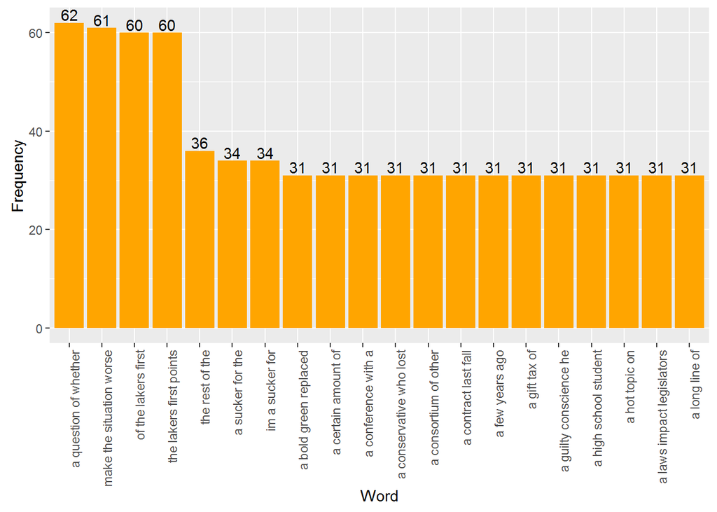

```r
#rank of top 20 4-gram words
ggplot(fou.Gram.Top20,aes(x=Word,y=Frequency))+geom_bar(stat="Identity",fill="orange")+geom_text(aes(label=Frequency),vjust=-0.2)+theme(axis.text.x = element_text(angle = 90, hjust = 1))
```

```r
##table of top 20 4-gram words
head(fou.Gram.Top20,20)
```

```
##                            Word Frequency
## 1179      a question of whether        62
## 39573  make the situation worse        61
## 46145       of the lakers first        60
## 63113   the lakers first points        60
## 63956           the rest of the        36
## 1443           a sucker for the        34
## 31106           im a sucker for        34
## 107       a bold green replaced        31
## 185         a certain amount of        31
## 244         a conference with a        31
## 246     a conservative who lost        31
## 247       a consortium of other        31
## 248        a contract last fall        31
## 424             a few years ago        31
## 501               a gift tax of        31
## 595      a guilty conscience he        31
## 659       a high school student        31
## 683              a hot topic on        31
## 765   a laws impact legislators        31
## 833              a long line of        31
```

To be improved: Take care of the rest symbols without affecting any English characters.

```r
#
# predictMatches <- function(toks, potentialAnswers) {
#   #toks <- tokenizeLines(sentence, 'en');
#   lastTok <- toks[[length(toks)]]
#   DT <- two.Gram.Sort[tok0==lastTok & tok1 %in% potentialAnswers];
#   DT[order(-freq)]
# }
#
# # q1
# s <- 'The guy in front of me just bought a pound of bacon, a bouquet, and a case'
# ans <- c('beer','cheese','soda','pretzels')
# predictMatches(s,ans)
#
# # q2
# s <- "You're the reason why I smile everyday. Can you follow me please? It would mean the"
# ans <- c('best','most','world','universe');
# predictMatches(s,ans)
#
# # q3
# s <- "Hey sunshine, can you follow me and make me the"
# ans <- c('happiest','saddest','bluest','smelliest')
# predictMatches(s,ans)

# f <- filter(fou.Gram.Sort[fou.Gram.Sort$fou.Gram %in% "good",])
#
# head(f,5)
# head(fou.Gram.Sort,5)
#
# g <- fou.Gram.Sort[grepl('^and i d ',fou.Gram.Sort$fou.Gram),]
# head(g,10)
#
# g <- fou.Gram.Sort[grepl('^me about his ',fou.Gram.Sort$fou.Gram),]
# head(g,10)
#
# g <- fou.Gram.Sort[grepl('^arctic monkeys this ',fou.Gram.Sort$fou.Gram),]
# head(g,10)
#
# g <- fou.Gram.Sort[grepl('^helps reduce your ',fou.Gram.Sort$fou.Gram),]
# head(g,10)
#
# g <- fou.Gram.Sort[grepl('^to take a ',fou.Gram.Sort$fou.Gram),]
# head(g,10)
#
# g <- fou.Gram.Sort[grepl('^to settle the ',fou.Gram.Sort$fou.Gram),]
# head(g,10)
#
# g <- fou.Gram.Sort[grepl('^groceries in each ',fou.Gram.Sort$fou.Gram),]
# head(g,10)
#
# g <- fou.Gram.Sort[grepl('^bottom to the ',fou.Gram.Sort$fou.Gram),]
# head(g,10)
#
# g <- fou.Gram.Sort[grepl('^bruises from playing ',fou.Gram.Sort$fou.Gram),]
# head(g,10)
#
# g <- fou.Gram.Sort[grepl('^adam sandler s ',fou.Gram.Sort$fou.Gram),]
# head(g,10)
#

write.csv(all,file="all.csv",row.names = FALSE)
write.csv(one.Gram.fra,file="1G_fra.csv",row.names = TRUE)
write.csv(one.Gram.Sort,file="1G_Sort.csv",row.names = TRUE)
write.csv(two.Gram.fra,file="2G_fra.csv",row.names = FALSE)
write.csv(two.Gram.Sort,file="2G_Sort.csv",row.names = FALSE)
write.csv(thr.Gram.fra,file="3G_fra.csv",row.names = FALSE)
write.csv(thr.Gram.Sort,file="3G_Sort.csv",row.names = FALSE)
write.csv(fou.Gram.fra,file="4G_fra.csv",row.names = FALSE)
write.csv(fou.Gram.Sort,file="4G_Sort.csv",row.names = FALSE)
```